# Low Birth Weight Logistic Regression Analysis - James Taylor

### This notebook uses data on births and if the child was underweight or not. It will explore the dataset, make some visualizations and create a logistic regression.

The variables and their descriptions are provided below. There are 9 of them in total.

| **Variable** | **Description** |
| --- | --- |
| ID | Identification Code |
| LOW | Low birth weight (0: >= 2500, 1: + 2500g) - target variable |
| AGE | Mother’s age in years |
| RACE | Race (1: White, 2: Black, 3: Other) |
| SMOKE | Smoking status during pregnancy (0: No, 1: Yes) |
| PTL | History of premature labor (0: None, 1: One, 2: Two, etc) |
| HT | History of hypertension (0: No, 1: Yes) |
| UI | Presence of Uterine irritability (0: No, 1: Yes) |
| FTV | Number of physician visits during the first trimester (0: None, 1: One, 2: Two, etc) |

Loading required packages for analysis.

```python
# PySpark Machine Learning Library
from pyspark.ml import Pipeline
from pyspark.ml.classification import LogisticRegression
from pyspark.ml.feature import HashingTF, Tokenizer
from pyspark.sql import Row, SQLContext

from pyspark.sql.functions import col, concat_ws
from pyspark.sql.types import StringType,BooleanType,DateType,IntegerType

import os
import sys
from pyspark import SparkConf
from pyspark import SparkContext
from pyspark.sql import SQLContext
from pyspark.sql.types import *

from pyspark.mllib.classification import LogisticRegressionWithSGD
from pyspark.mllib.regression import LabeledPoint
from numpy import array

from pyspark.ml.evaluation import MulticlassClassificationEvaluator
# Library for confusion matrix, precision, test error
from pyspark.mllib.evaluation import MulticlassMetrics
# Library For Area under ROC curve and Area under precision-recall curve
from pyspark.mllib.evaluation import BinaryClassificationMetrics

# Assign resources to the application
sqlContext = SQLContext(sc)

# packages for data analysis
import numpy as np
import pandas as pd
```

```
Waiting for a Spark session to start...
Spark Initialization Done! ApplicationId = app-20210223160859-0000
KERNEL_ID = c0a3702b-f08e-441c-9bf1-cc5f1ffaedc7
```

## Credentials

Load the data as SparkSession Dataframe.

```python
# credentials
import ibmos2spark
credentials = {
    'endpoint': 'https://s3-api.us-geo.objectstorage.service.networklayer.com',
    'service_id': 'iam-ServiceId-9741de6e-8fa3-453a-8abf-8f320e6c3dda',
    'iam_service_endpoint': 'https://iam.cloud.ibm.com/oidc/token',
    'api_key': 'aJQ6YASukVQxKXsEeDzrtRMJRUHdwYOxKcluDtYB8qtT'
}

configuration_name = 'os_48736ac24f09412fbfbc0e59e61265a2_configs'
cos = ibmos2spark.CloudObjectStorage(sc, credentials, configuration_name, 'bluemix_cos')


# import data
from pyspark.sql import SparkSession
spark = SparkSession.builder.getOrCreate()
df_data_1 = spark.read\
  .format('org.apache.spark.sql.execution.datasources.csv.CSVFileFormat')\
  .option('header', 'true')\
  .load(cos.url('lowbwt.csv', 'apachesparktutorial-donotdelete-pr-obnjojwltryuds'))

# assign the df a new name
df = df_data_1
del(df_data_1) # deletes original df

df.take(5)
```

```
[Row(ID='85', LOW='0', AGE='19', RACE='2', SMOKE='0', PTL='0', HT='0', UI='1', FTV='0'),
 Row(ID='86', LOW='0', AGE='33', RACE='3', SMOKE='0', PTL='0', HT='0', UI='0', FTV='3'),
 Row(ID='87', LOW='0', AGE='20', RACE='1', SMOKE='1', PTL='0', HT='0', UI='0', FTV='1'),
 Row(ID='88', LOW='0', AGE='21', RACE='1', SMOKE='1', PTL='0', HT='0', UI='1', FTV='2'),
 Row(ID='89', LOW='0', AGE='18', RACE='1', SMOKE='1', PTL='0', HT='0', UI='1', FTV='0')]
```

## Transform Data

The output above shows that the variables stored numbers as stings. We want to change this now to make problems later on less likely.

```python
# print Schema of dataframe showing variable types
print('Before...')
df.printSchema()

# loops though every column in dataframe
for cols in df.columns:
    df = df.withColumn(cols ,df[cols].cast(IntegerType())) # assigns every column as integer

print('\nAfter...')
df.printSchema()   # all variable types should be shown as 'integer'
```

```
Before...
root
 |-- ID: string (nullable = true)
 |-- LOW: string (nullable = true)
 |-- AGE: string (nullable = true)
 |-- RACE: string (nullable = true)
 |-- SMOKE: string (nullable = true)
 |-- PTL: string (nullable = true)
 |-- HT: string (nullable = true)
 |-- UI: string (nullable = true)
 |-- FTV: string (nullable = true)


After...
root
 |-- ID: integer (nullable = true)
 |-- LOW: integer (nullable = true)
 |-- AGE: integer (nullable = true)
 |-- RACE: integer (nullable = true)
 |-- SMOKE: integer (nullable = true)
 |-- PTL: integer (nullable = true)
 |-- HT: integer (nullable = true)
 |-- UI: integer (nullable = true)
 |-- FTV: integer (nullable = true)
```

## Explore the Data

Understand the variables and their distributions.

```python
# describe all coulumns in df
columns = df.columns
df.select(columns).describe().toPandas().transpose()
```

|  | 0 | 1 | 2 | 3 | 4 |
| --- | --- | --- | --- | --- | --- |
| summary | count | mean | stddev | min | max |
| ID | 189 | 121.07936507936508 | 63.30363378715761 | 4 | 226 |
| LOW | 189 | 0.31216931216931215 | 0.46460925347537996 | 0 | 1 |
| AGE | 189 | 23.238095238095237 | 5.2986779334042655 | 14 | 45 |
| RACE | 189 | 1.8465608465608465 | 0.9183422406772138 | 1 | 3 |
| SMOKE | 189 | 0.3915343915343915 | 0.48938984496358745 | 0 | 1 |
| PTL | 189 | 0.19576719576719576 | 0.4933419132673032 | 0 | 3 |
| HT | 189 | 0.06349206349206349 | 0.24449356296290053 | 0 | 1 |
| UI | 189 | 0.14814814814814814 | 0.35619033170970177 | 0 | 1 |
| FTV | 189 | 0.7936507936507936 | 1.0592861429875455 | 0 | 6 |

### Check the Balance of the target variable

```python
print('There are ' + str(df.count()) + ' observations')
print('\nTable of birth weights')

# Number of Low and Normal weight births
df.groupby('LOW').count().show()

perc_LOW = round((df[df.LOW == '1'].count()/df.count()*100),2)  # count of True LOW values and divides by count to get percentage
print(str(perc_LOW) + '% of the data is a under weight birth')
```

```
There are 189 observations

Table of birth weights
+---+-----+
|LOW|count|
+---+-----+
|  1|   59|
|  0|  130|
+---+-----+

31.22% of the data is a under weight birth
```

### History of Premature Labor

```python
# Number of under/normal weight births by history of premature labor
df.crosstab('LOW', 'PTL').show()
```

```
+-------+---+---+---+---+
|LOW_PTL|  0|  1|  2|  3|
+-------+---+---+---+---+
|      1| 41| 16|  2|  0|
|      0|118|  8|  3|  1|
+-------+---+---+---+---+
```

Does a history of premature labor correlate to low birth weights?

The answer is maybe. There is not a large sample size of women that have history of premature labor, but of the ones in this dataset we see higher rates of low birth weights than women with no such history. More research would have to be done to confirm this.

### Age

Let's see if older mothers have a higher propencity to have under weight births. The below code creates a dataframe with the requisite data.

```python
import matplotlib.pyplot as plt

# get data for plot
dfplt1=df.crosstab('AGE', 'LOW').toPandas() # crosstab of age and birthweights
dfplt1 = dfplt1.sort_values('AGE_LOW')      # sort by age
dfplt1.columns = ['AGE', 'Normal', 'Under Weight']  #rename variables so they appear correct on graph
```

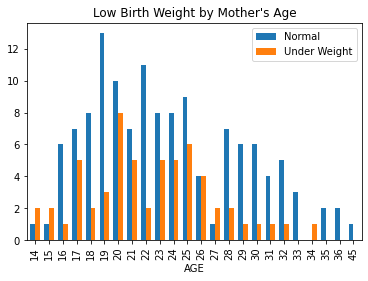

```python
# plot data
dfplt1.plot.bar(x="AGE", legend=True, title="Low Birth Weight by Mother's Age", width=.7)
```

The above plot does not show a strong relationship between mother's age and under weight birth. The safest age group for mother's appears to be from about 28 on after. It looks like this is where the lowest under-weight birth ratio exists in our data. Younger mothers look to be higher risk.

### Age Histogram

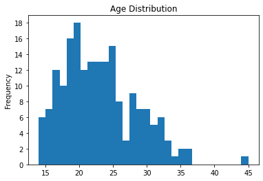

```python
plt.yticks(np.arange(0, 20, 2))     # sets y-ticks
df.toPandas()["AGE"].plot.hist(x="AGE", title="Age Distribution", bins=30)
```

There appears to be a potential outier in the data, one mother that was 45 years old. It clearly stands out when compared to the rest of our data. There also is an unexplicable dip in mothers around 26, which is probably a sampling error.

### Smoking

```python
# Number of under/normal weight births by mother's smoking data
df.crosstab('LOW', 'SMOKE').show()
df.groupby(['SMOKE']).agg({"LOW": "AVG"}).toPandas()  # average of LOW value for each smoking category (True/False)
```

```
+---------+---+---+
|LOW_SMOKE|  0|  1|
+---------+---+---+
|        1| 29| 30|
|        0| 86| 44|
+---------+---+---+
```

|  | SMOKE | avg(LOW) |
| --- | --- | --- |
| 0 | 1 | 0.405405 |
| 1 | 0 | 0.252174 |

The crosstab reveals the chance of having a under weight birth is probably higher if the mother was smoking during pregnancy. To confirm this, the average LOW value was claculated for each smoking status. It clearly shows mpregnant smokers have higher chances of an under weight birth becuase the average is higher (the closser to 1 the more smokers had under-weight births). Taking the avergae also controls for the different amount of smoker/non-smokers in the data.

### Race

```python
# get average of LOW value by race category
low_vs_race=df.groupby(['RACE']).agg({"LOW": "AVG"}).toPandas()
low_vs_race.RACE = ('White', 'Other', 'Black')
low_vs_race
```

|  | RACE | avg(LOW) |
| --- | --- | --- |
| 0 | White | 0.239583 |
| 1 | Other | 0.373134 |
| 2 | Black | 0.423077 |

There seems to be a significant difference across races on the likelyhood of having and underweight birth. Let's graph it.

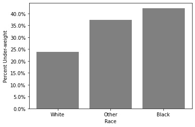

```python
import matplotlib.ticker as mtick

# plot average values for each race
plt.bar(low_vs_race['RACE'], low_vs_race["avg(LOW)"], color='grey')
plt.xlabel('Race')                   # name x-axis
plt.ylabel('Percent Under-weight')   # name y-axis
plt.gca().yaxis.set_major_formatter(mtick.PercentFormatter(1))    # convert y-ticks into percent
```

Averages control for the varying amount of observations for each race. That way it is an apples-to-apples comparison between races on their likelyhood for under-weight births.

### Hypertension

```python
# number of low/normal weight births by hypertension data
df.crosstab('LOW', 'HT').show()
df.groupby(['HT']).agg({"LOW": "AVG"}).toPandas()  # average LOW vlaue for each hypertension category
```

```
+------+---+---+
|LOW_HT|  0|  1|
+------+---+---+
|     1| 52|  7|
|     0|125|  5|
+------+---+---+
```

|  | HT | avg(LOW) |
| --- | --- | --- |
| 0 | 1 | 0.583333 |
| 1 | 0 | 0.293785 |

Looking at the averages, it looks like mothers with hypertension are much more likely to have a under-weight birth (over 50%). However, looking at the crosstab we see only 12 mothers have hypertension. This is not a large sample size to make inferences from.

### Uterine irritability

```python
# number of low/normal weight births by Uterine irritability data
df.crosstab('LOW', 'UI').show()
df.groupby(['UI']).agg({"LOW": "AVG"}).toPandas()    # average LOW vlaue for each hypertension category
```

```
+------+---+---+
|LOW_UI|  0|  1|
+------+---+---+
|     1| 45| 14|
|     0|116| 14|
+------+---+---+
```

|  | UI | avg(LOW) |
| --- | --- | --- |
| 0 | 1 | 0.500000 |
| 1 | 0 | 0.279503 |

Uterine irritability appears similar to hypertension because mothers who have it have higher ratio's of under-weight births but the observations of mothers with the condition are low.

### Physician Visits During First Trimester

```python
# number of low/normal birth weights for each value of physician visits
df.crosstab('LOW', 'FTV').show()
low_vs_ftv = df.groupby(['FTV']).agg({"LOW": "AVG"}).toPandas() # average LOW vlaue for each value of pysician visits
low_vs_ftv = low_vs_ftv.sort_values('FTV')      # sort by age
low_vs_ftv
```

```
+-------+---+---+---+---+---+---+
|LOW_FTV|  0|  1|  2|  3|  4|  6|
+-------+---+---+---+---+---+---+
|      1| 36| 11|  7|  4|  1|  0|
|      0| 64| 36| 23|  3|  3|  1|
+-------+---+---+---+---+---+---+
```

|  | FTV | avg(LOW) |
| --- | --- | --- |
| 5 | 0 | 0.360000 |
| 0 | 1 | 0.234043 |
| 4 | 2 | 0.233333 |
| 2 | 3 | 0.571429 |
| 3 | 4 | 0.250000 |
| 1 | 6 | 0.000000 |

The under-weight birth ratio varies across the values.

## Transformations

It doesn't make sense for us to include the RACE variable as it was provided. It has numerical values for different races and the logistic regression will treat the variable as any other numerical value. Instead we will ctreate two dummy variables for 'White' and 'Black' races. This will let us inspect the estimate of each race indivdualy. Creating these variables will make the given RACE variable not needed.

```python
# The code below creates 2 new empty columns in the pyspark dataframe.
# They have the 'bool' part of their column name to signify they are boolean variable (True/False).
from pyspark.sql.functions import lit

df = df.withColumn('WHITEbool', lit(None).cast(IntegerType()))
df = df.withColumn('BLACKbool', lit(None).cast(IntegerType()))
df.printSchema()
```

```
root
 |-- ID: integer (nullable = true)
 |-- LOW: integer (nullable = true)
 |-- AGE: integer (nullable = true)
 |-- RACE: integer (nullable = true)
 |-- SMOKE: integer (nullable = true)
 |-- PTL: integer (nullable = true)
 |-- HT: integer (nullable = true)
 |-- UI: integer (nullable = true)
 |-- FTV: integer (nullable = true)
 |-- WHITEbool: integer (nullable = true)
 |-- BLACKbool: integer (nullable = true)
```

```python
# This code populates the new dummy variables with 1 or 0 depending on the value of the RACE variable provided
# in the dataset.
from pyspark.sql.functions import when

df = df.withColumn("WHITEbool", when(df.RACE == 1, 1).otherwise(0))\
       .withColumn("BLACKbool", when(df.RACE == 2, 1).otherwise(0))     # each column is True when the race of mother matches the column

df.show(15)
```

```
+---+---+---+----+-----+---+---+---+---+---------+---------+
| ID|LOW|AGE|RACE|SMOKE|PTL| HT| UI|FTV|WHITEbool|BLACKbool|
+---+---+---+----+-----+---+---+---+---+---------+---------+
| 85|  0| 19|   2|    0|  0|  0|  1|  0|        0|        1|
| 86|  0| 33|   3|    0|  0|  0|  0|  3|        0|        0|
| 87|  0| 20|   1|    1|  0|  0|  0|  1|        1|        0|
| 88|  0| 21|   1|    1|  0|  0|  1|  2|        1|        0|
| 89|  0| 18|   1|    1|  0|  0|  1|  0|        1|        0|
| 91|  0| 21|   3|    0|  0|  0|  0|  0|        0|        0|
| 92|  0| 22|   1|    0|  0|  0|  0|  1|        1|        0|
| 93|  0| 17|   3|    0|  0|  0|  0|  1|        0|        0|
| 94|  0| 29|   1|    1|  0|  0|  0|  1|        1|        0|
| 95|  0| 26|   1|    1|  0|  0|  0|  0|        1|        0|
| 96|  0| 19|   3|    0|  0|  0|  0|  0|        0|        0|
| 97|  0| 19|   3|    0|  0|  0|  0|  1|        0|        0|
| 98|  0| 22|   3|    0|  0|  1|  0|  0|        0|        0|
| 99|  0| 30|   3|    0|  1|  0|  1|  2|        0|        0|
|100|  0| 18|   1|    1|  0|  0|  0|  0|        1|        0|
+---+---+---+----+-----+---+---+---+---+---------+---------+
only showing top 15 rows
```

The two columns furthest to the right are the newly populated dummy variables. Obviously when someone is white (RACE = 1) the WHITEbool dummy varible should be True and BLACKbool dummy should be False. The two dummy should never both be True, or both = 1 becuase someone cannot be black and white given the data we originaly recived. However, they can both be False becuase there is the 'Other' race category, which there is no dummy variable for. There is no varible for 'Other' becuase it would cause a perfect-multicolinearity problem in the regression.

```python
# Lets look at the variables and see which ones should go in the model
# get and decribe all coulumns in df
df.select('*').describe().toPandas().transpose()
```

|  | 0 | 1 | 2 | 3 | 4 |
| --- | --- | --- | --- | --- | --- |
| summary | count | mean | stddev | min | max |
| ID | 189 | 121.07936507936508 | 63.30363378715761 | 4 | 226 |
| LOW | 189 | 0.31216931216931215 | 0.46460925347537996 | 0 | 1 |
| AGE | 189 | 23.238095238095237 | 5.2986779334042655 | 14 | 45 |
| RACE | 189 | 1.8465608465608465 | 0.9183422406772138 | 1 | 3 |
| SMOKE | 189 | 0.3915343915343915 | 0.48938984496358745 | 0 | 1 |
| PTL | 189 | 0.19576719576719576 | 0.4933419132673032 | 0 | 3 |
| HT | 189 | 0.06349206349206349 | 0.24449356296290053 | 0 | 1 |
| UI | 189 | 0.14814814814814814 | 0.35619033170970177 | 0 | 1 |
| FTV | 189 | 0.7936507936507936 | 1.0592861429875455 | 0 | 6 |
| WHITEbool | 189 | 0.5079365079365079 | 0.5012648641511006 | 0 | 1 |
| BLACKbool | 189 | 0.13756613756613756 | 0.34535889768317607 | 0 | 1 |

The above shows the loayout of the columns. This helps us see which columns will go into the model as features. Below is a function that parses the data so we can tokenize it and make feature vectors

### Feature Vectors

```python
# concatenate the columns into one named 'vectors' each value seperated by space
col_vectors = df.select(df.ID, concat_ws(' ',df.AGE, df.SMOKE ,df.PTL ,df.HT ,df.UI ,df.FTV ,df.WHITEbool ,df.BLACKbool).alias("vector"))
# df with ID and concatenated vectors

# df with ID and LOW value
col_LOW = df.select('ID', 'LOW')

# join two dfs on ID so values remain in the same row
col_vectors = col_vectors.join(col_LOW, on=["ID"])

# rename df for the model
df_model = col_vectors

df_model.take(5)
```

```
[Row(ID=85, vector='19 0 0 0 1 0 0 1', LOW=0),
 Row(ID=86, vector='33 0 0 0 0 3 0 0', LOW=0),
 Row(ID=87, vector='20 1 0 0 0 1 1 0', LOW=0),
 Row(ID=88, vector='21 1 0 0 1 2 1 0', LOW=0),
 Row(ID=89, vector='18 1 0 0 1 0 1 0', LOW=0)]
```

Below is another way of vectorizing the input variables. I prefer the above method becuase it is more obvious what the code is doing.

```python
#LabeledDocument = Row("ID", "DATA", "LOW")

# Define a function that parses each row in CSV file and returns an object of type LabeledDocument

#def parseDocument(line):
#    values = [str(x) for x in line.split(',')]
#
#    textValue = str(values[2]) + " " + str(values[4]) + " " + str(values[5]) + " " + str(values[6]) + " " + str(values[7])\
#                               + " " + str(values[8]) + " " + str(values[9])
#
#    return LabeledDocument(values[0], textValue, values[1])
#
#
#documents = df.filter(lambda s: "RACE" not in s).map(parseDocument)
#df_model_2 = documents.toDF() # ToDataFrame
#df_model_2.take(5)
```

The above is a parsing function that takes the dataframe and parses it so that it creates another dataframe with three columns- the ID value of the observation, a vectorized string column with the desired model input vaiables seperated by a space, and if the observation was a low birthweight or not.

## Train/Test Split

```python
(df_train, df_test) = df_model.randomSplit([0.8, 0.2], seed=8)   # 80% to train, 20% to test
print ("Number of records in the training set: " + str(df_train.count()))
print ("Number of records in the test set: " + str(df_test.count()))
# Output first 20 records in the training set
print ("First 20 records in the training set: ")
df_train.head(10)
```

```
Number of records in the training set: 161
Number of records in the test set: 28
First 20 records in the training set:
```

```
[Row(ID=4, vector='28 1 1 0 1 0 0 0', LOW=1),
 Row(ID=10, vector='29 0 0 0 1 2 1 0', LOW=1),
 Row(ID=11, vector='34 1 0 1 0 0 0 1', LOW=1),
 Row(ID=13, vector='25 0 1 1 0 0 0 0', LOW=1),
 Row(ID=15, vector='25 0 0 0 1 0 0 0', LOW=1),
 Row(ID=16, vector='27 0 0 0 0 0 0 0', LOW=1),
 Row(ID=17, vector='23 0 0 0 1 1 0 0', LOW=1),
 Row(ID=18, vector='24 0 1 0 0 1 0 1', LOW=1),
 Row(ID=19, vector='24 0 0 1 0 0 0 0', LOW=1),
 Row(ID=20, vector='21 1 0 1 0 1 1 0', LOW=1)]
```

## Logistic Regression

```python
# set up Logistic Regression using Pipeline of SparkML
tokenizer = Tokenizer(inputCol="vector", outputCol="words")
hashingTF = HashingTF(inputCol=tokenizer.getOutputCol(), outputCol="features")
lr = LogisticRegression(labelCol='LOW', maxIter=10, regParam=0.01)
pipeline = Pipeline(stages=[tokenizer, hashingTF, lr])



model = pipeline.fit(df_train)
```

Get Predictions.

```python
# has probabilities/predictions for each observation in train/test dataset
pred_test = model.transform(df_test)     # predictions on test data
pred_train = model.transform(df_train)   # predicitions on train data
pred_test.show(5)
```

```
+---+----------------+---+--------------------+--------------------+--------------------+--------------------+----------+
| ID|          vector|LOW|               words|            features|       rawPrediction|         probability|prediction|
+---+----------------+---+--------------------+--------------------+--------------------+--------------------+----------+
| 23|19 1 2 0 1 0 1 0|  1|[19, 1, 2, 0, 1, ...|(262144,[12524,76...|[1.33245798464966...|[0.79124692361519...|       0.0|
| 34|19 1 0 0 1 0 1 0|  1|[19, 1, 0, 0, 1, ...|(262144,[76985,92...|[1.43802266490101...|[0.80814826300020...|       0.0|
| 37|17 1 1 0 1 0 0 0|  1|[17, 1, 1, 0, 1, ...|(262144,[76985,92...|[-0.5862318524752...|[0.35749990861865...|       1.0|
| 46|25 0 1 0 0 1 0 0|  1|[25, 0, 1, 0, 0, ...|(262144,[76985,92...|[0.15804268577933...|[0.53942863655615...|       0.0|
| 47|20 0 0 0 0 0 0 0|  1|[20, 0, 0, 0, 0, ...|(262144,[76985,90...|[1.44349841235863...|[0.80899581610761...|       0.0|
+---+----------------+---+--------------------+--------------------+--------------------+--------------------+----------+
only showing top 5 rows
```

```python
# check the data from the model on the test data
selected = pred_test.select('ID', 'probability', 'prediction')
selected.head(10)
```

```
[Row(ID=23, probability=DenseVector([0.7912, 0.2088]), prediction=0.0),
 Row(ID=34, probability=DenseVector([0.8081, 0.1919]), prediction=0.0),
 Row(ID=37, probability=DenseVector([0.3575, 0.6425]), prediction=1.0),
 Row(ID=46, probability=DenseVector([0.5394, 0.4606]), prediction=0.0),
 Row(ID=47, probability=DenseVector([0.809, 0.191]), prediction=0.0),
 Row(ID=62, probability=DenseVector([0.5122, 0.4878]), prediction=0.0),
 Row(ID=76, probability=DenseVector([0.6579, 0.3421]), prediction=0.0),
 Row(ID=78, probability=DenseVector([0.3369, 0.6631]), prediction=1.0),
 Row(ID=86, probability=DenseVector([0.986, 0.014]), prediction=0.0),
 Row(ID=96, probability=DenseVector([0.9534, 0.0466]), prediction=0.0)]
```

Below is how the model predicted on the test data. It made 22 'not under-weight' predictions and 6 'under-weight'.

```python
#Tabulate the predictions
pred_test.select("prediction").groupBy("prediction").count().show(truncate=False)
```

```
+----------+-----+
|prediction|count|
+----------+-----+
|0.0       |22   |
|1.0       |6    |
+----------+-----+
```

The crosstab below shows how model's performance on the test data. It made 16 True-Negative (non-under-weight births were predicted accuratly) and 2 True-Positive predictions (under-weight births were predicted correctly). Conversly the model made 4 False-Positive and 6 False-Negative predictions.

```python
pred_test.crosstab('LOW', 'prediction').show()
```

```
+--------------+---+---+
|LOW_prediction|0.0|1.0|
+--------------+---+---+
|             1|  6|  2|
|             0| 16|  4|
+--------------+---+---+
```

```python
pred_test.select("LOW","prediction").show(10)
```

```
+---+----------+
|LOW|prediction|
+---+----------+
|  1|       0.0|
|  1|       0.0|
|  1|       1.0|
|  1|       0.0|
|  1|       0.0|
|  1|       0.0|
|  1|       0.0|
|  1|       1.0|
|  0|       0.0|
|  0|       0.0|
+---+----------+
only showing top 10 rows
```

Model Evaluation Stats on Trainning and Test Data

```python
z = 0            # just for printing in loop
for x in (df_train, df_test):     # loop through both train and test dataframes to test model's metrics
    y = ['train', 'test']        # just for printing later

    pred_lr = model.transform(x).select("prediction", "LOW")
    pred_lr = pred_lr.withColumn('LOW' ,pred_lr['LOW'].cast(DoubleType()))   # need to convert LOW from int to Double because prediction is Double
    eval_lr = MulticlassClassificationEvaluator(labelCol="LOW", predictionCol="prediction", metricName="accuracy")
    accuracy_lr = eval_lr.evaluate(pred_lr)
    # create RDD
    predictionAndLabels_lr = pred_lr.rdd
    metrics_lr = MulticlassMetrics(predictionAndLabels_lr)
    precision_lr = metrics_lr.precision(1.0)
    recall_lr = metrics_lr.recall(1.0)
    f1Measure_lr = metrics_lr.fMeasure(1.0, 1.0)

    print("Model evaluation for the " + str(y[z]) + " data")
    print("Accuracy = %s" %accuracy_lr)
    print("Error = %s" % (1-accuracy_lr))
    print("Precision = %s" %precision_lr)
    print("Recall = %s" %recall_lr)
    print("F1 Measure = %s" % f1Measure_lr + "\n")

    z = z +1      # just for printing in loop
```

```
Model evaluation for the train data
Accuracy = 0.7080745341614907
Error = 0.2919254658385093
Precision = 0.5666666666666667
Recall = 0.3333333333333333
F1 Measure = 0.4197530864197531

Model evaluation for the test data
Accuracy = 0.6428571428571429
Error = 0.3571428571428571
Precision = 0.3333333333333333
Recall = 0.25
F1 Measure = 0.28571428571428575
```

The model berformed better on the train data which is to be expected.

```python
# Redoing this section of code (same as above) to make sure the test data is assigned correctly (unlike the loop above)
pred_lr = model.transform(df_test).select("prediction", "LOW")
pred_lr = pred_lr.withColumn('LOW' ,pred_lr['LOW'].cast(DoubleType()))
predictionAndLabels_lr = pred_lr.rdd
bin_lr=BinaryClassificationMetrics(predictionAndLabels_lr)

# Area under precision-recall curve
print("Area under PR = %s" % bin_lr.areaUnderPR)
# Area under Receiver operating characteristic curve
print("Area under ROC = %s" % bin_lr.areaUnderROC)
```

```
Area under PR = 0.31547619047619047
Area under ROC = 0.525
```

```python
# Get ROC data from model
#ROC_data = model.summary.roc.select('FPR', 'TPR').toPandas()
#print(ROC_data[:10])

model.stages[2].summary.roc.show()
```

```
+--------------------+--------------------+
|                 FPR|                 TPR|
+--------------------+--------------------+
|                 0.0|                 0.0|
|                 0.0|  0.0196078431372549|
| 0.00909090909090909|  0.0392156862745098|
| 0.00909090909090909|0.058823529411764705|
| 0.00909090909090909|  0.0784313725490196|
| 0.01818181818181818|  0.0784313725490196|
| 0.01818181818181818| 0.09803921568627451|
| 0.01818181818181818| 0.13725490196078433|
| 0.01818181818181818| 0.17647058823529413|
| 0.01818181818181818| 0.19607843137254902|
| 0.02727272727272727| 0.19607843137254902|
| 0.02727272727272727| 0.21568627450980393|
| 0.03636363636363636| 0.21568627450980393|
| 0.03636363636363636|  0.2549019607843137|
|0.045454545454545456|  0.2549019607843137|
| 0.05454545454545454|  0.2549019607843137|
| 0.07272727272727272| 0.27450980392156865|
| 0.09090909090909091| 0.29411764705882354|
|                 0.1| 0.29411764705882354|
| 0.11818181818181818|  0.3333333333333333|
+--------------------+--------------------+
only showing top 20 rows
```

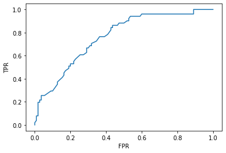

```python
# Plot the ROC values on the test dataset

#ROC_data.plot(x='FPR', y='TPR', legend=False)
#plt.ylabel('TPR')      # labels y axis


ROC=model.stages[2].summary.roc
df_ROC=ROC.toPandas()

df_ROC.plot(x='FPR', y='TPR', legend=False)
plt.ylabel('TPR')
```